# ActiveDeveloperEDA-Slide slides

## Dataset Overview:

> This dataset has 4 tables:
> - User table: introduces user profile including country, signup date, user id and company id
> - Event details table: describes each type of events and the platform that they take place
> - Company table: company id and its recorded type
> - Event table: events on platform from 2019 Feb to 2021 Feb

> Data quality issues: the majority of dataset is quite clean and full, only contains some empty data in user and company table, such as 0.22% in SignupDate is empty, 0.19% in CompanyId is empty, 13.26% in Country is empty, 0.19% in RecordType is empty.

## Investigation Overview:

> 4 tables described above are merged together to be looked at:
> - Trend of events throughout the whole period
> - Trend of users throughout the whole period
> - Developers' behaviors on platform (compared with other types of users)
> - Recommended KPIs in order to track growth of customer base

## Definitions:

- Active developer - original: a user that has performed at least one of four specific activities in the past 30 days
- Active developer - adjusted in order to be tracked: a user that has performed at least one of four specific activities in one activity month
- Developer: a user who's ever performed one developer activity throughout the whole period
- Developer event: ModelDeployed, SandboxDeployed, TeamserverCommit, WmDeploySucceeded

## Trend of events

> This part is to dig into trend of number of events categorized by variables.

```
Attention: Values smaller than 0.5% are not shown.
```

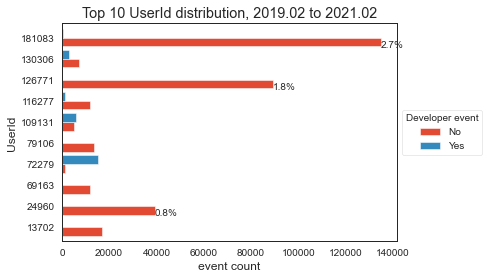

```python
cat_plot(main_, cols[0])
```

- 6 of top 10 users that performed the most events have no or very small number of developer events.

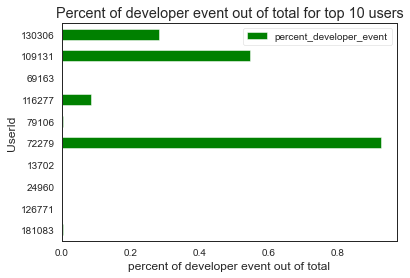

```python
top_10 = main_.groupby('UserId').agg({'Developer':'sum','EventId':'count'})
top_10 = top_10.sort_values(by='EventId', ascending=False).head(10)
top_10['percent_developer_event'] = top_10['Developer'] / top_10['EventId']
top_10.drop(['Developer','EventId'], axis =1).plot(kind='barh', color='green')
plt.title('Percent of developer event out of total for top 10 users')
plt.xlabel('percent of developer event out of total');
```

```
Attention: Values smaller than 0.5% are not shown.
```

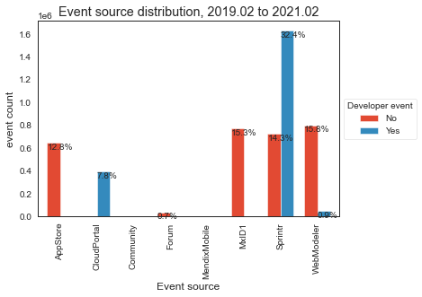

```python
cat_plot(main_, cols[2])
```

- Developer events mostly take place on Sprintr (32.4%), cloud portal (7.8%) and web modeler (0.9%).
- Only cloud portal is exclusively used by developer, sprintr and webmodeler are also used for other events (14.3%, 15.8%).
- **Strengthening mentioned sources could help with boosting developer's experience.**

```
Attention: Values smaller than 0.5% are not shown.
```

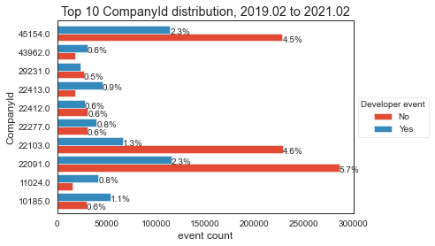

```python
cat_plot(main_, cols[3])
```

```
Attention: Values smaller than 0.5% are not shown.
```

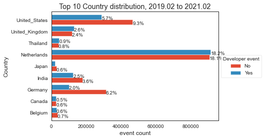

```python
cat_plot(main_, cols[4])
```

- In Netherlands, developer events and other events are equivalent (around 18%), UK (deverloper events 2.6% vs. non developer events 2.4%) is more interested in using it as a developer platform, the same with Thailand (0.9% developer events vs. 0.8% non developer events).
- **Netherlands is relatively mature, US and DE have big potentials.**

```
Attention: Values smaller than 0.5% are not shown.
```

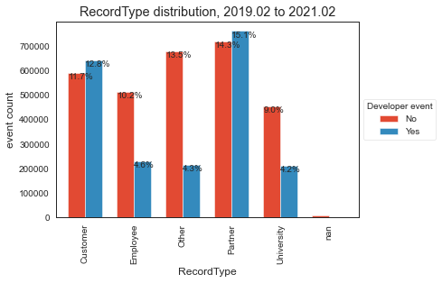

```python
cat_plot(main_, cols[5])
```

- Partner contributed to the most of events (29.4%), it seems they are also slightly more interested in developer events (15.1%).
- Customers also have high percent of developer events (12.8%).
- University and employees have more other events.

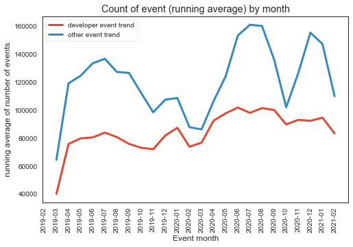

```python
# special for event month and signup year
fig, ax = plt.subplots(figsize=(8,5))
by_month = main_.groupby(['Timestamp','Developer'], dropna=False)['EventId'].count().unstack()
by_month['running_average_developer'] = by_month[1].rolling(2).mean()
by_month['running_average_other'] = by_month[0].rolling(2).mean()
x = by_month.index
y = by_month['running_average_developer'].values
z = by_month['running_average_other'].values

ax.plot(x, y, label ='developer event trend',lw=3)
ax.plot(x, z, label = 'other event trend',lw=3)
ax.legend()
plt.setp(ax.get_xticklabels(), rotation=90)
ax.set_xlabel('Event month')
ax.set_ylabel('running average of number of events')
ax.set_title('Count of event (running average) by month');
```

- Developer events have a more stable trend, proving that developers are probably more committed to platform once signed up.
- Other events fluctuate a lot.

## Trend of users

> This part is to look at number of active users in each reporting month as well as average events they performed.

> *Active means active in a reporting month instead of active in past 30 days.*

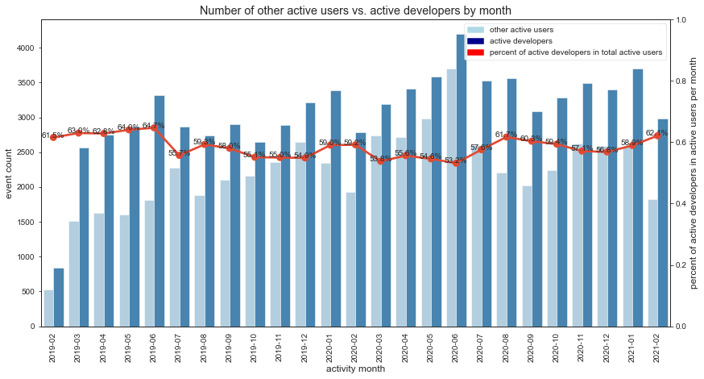

```python
# visualize number of active users and active developers in respective reporting month
plt.figure(figsize=(14,7))

ax = sb.countplot(data=by_user, x='Timestamp', hue = 'Active', palette='Blues')
plt.legend([])
plt.setp(ax.get_xticklabels(), rotation=90)
ax.set_ylabel('event count')
data = by_user.groupby('Timestamp', as_index =False, dropna=False)['Active'].mean()
ax2 = ax.twinx()
sb.pointplot(data=data, x='Timestamp', y='Active', ax=ax2)
ax2.set_ylim(0,1)
plt.xticks(rotation = 90)
ax.set_xlabel('activity month')
ax2.set_ylabel('percent of active developers in active users per month')
plt.title('Number of other active users vs. active developers by month')

# set a readable legend
light_patch = mpatches.Patch(color='lightblue', label='other active users')
dark_patch = mpatches.Patch(color='darkblue', label='active developers')
red_patch = mpatches.Patch(color='red', label='percent of active developers in total active users')
plt.legend(handles=[light_patch, dark_patch, red_patch])


# annotate
for i in range(0, data.shape[0]):
    perc = data['Active'].iloc[i]
    perc_shown = '{:.1f}%'.format(perc*100)
    plt.text(i, perc, perc_shown, ha = 'center')
```

- Number of developers have always been more than other users, maintaining at 53% to 65% of total users.
- As of **2019 Mar**, both soared, in **2020 Jun** reached the peak then dropped in **2020 Sep**.
- **Regardless of change in number of users, developers maintain a stable portion in customer base.**

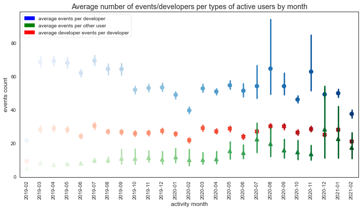

```python
# bring events and users together to look at average events per user
plt.figure(figsize=(12,6))
sb.pointplot(data=by_user[by_user['Active']==1], x='Timestamp', y = 'total_events', palette ='Blues')
sb.pointplot(data=by_user[by_user['Active']==1], x='Timestamp', y = 'total_developer_events', palette ='Reds', markers ='X')
sb.pointplot(data=by_user[by_user['Active']==0], x='Timestamp', y = 'total_events', palette ='Greens', markers='^', dodge=3)
plt.xticks(rotation=90)
plt.xlabel('activity month')
plt.ylabel('events count')
plt.title('Average number of events/developers per types of active users by month')
plt.setp(ax.get_xticklabels(), rotation=90)
# set a readable legend
blue_patch = mpatches.Patch(color='blue', label='average events per developer')
green_patch = mpatches.Patch(color='green', label='average events per other user')
red_patch = mpatches.Patch(color='red', label='average developer events per developer')
plt.legend(handles=[blue_patch, green_patch, red_patch]);
```

- Developers turn to perform much more events than other users on average, either other events or developer events, however the gap is smaller recently.
- Developers in other activities also show some extreme values as of **2020 Jun**.
- Average developer events are quite stable in trend, slightly increasing from 20 to 30.
- Average events performed by other users are increasing over years, as of **2019 Sep**, there're also some extreme values in numbers and std is bigger.

## Developers' behaviors

> This part is to identify characteristics of developers:

> > In comparison to other users, if developers have anything special.  
> > What most developers start with.  
> > Apart from developer events, what other events developers perform.

> *Developers: a user who's ever performed one developer activity throughout the whole period*

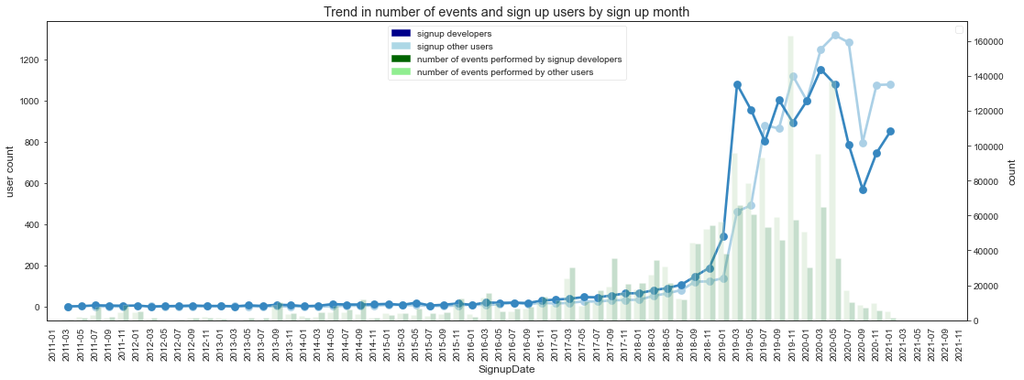

```python
# add developer identifier back to user dataset, meaning who's ever a developer
plt.figure(figsize=(18,6))
by_signup = by_user2.groupby(['SignupDate','Active'], as_index=False, dropna=False).agg({'UserId':'count'})
ax1 = sb.pointplot(data=by_signup, x='SignupDate', y='UserId', hue='Active', palette='Blues', order=signup_cat[::2])
plt.legend([])

plt.ylabel('user count')
ax3 = ax1.twinx()
sb.countplot(data=main_.dropna(), x='SignupDate',palette='Greens', hue = 'Developer', order = signup_cat[::2], ax=ax3, alpha=0.3)
plt.xticks(rotation=90)
ax3.set_xlabel('Sign up year')
plt.title('Trend in number of events and sign up users by sign up month')
plt.setp(ax1.get_xticklabels(), rotation=90)

# set a readable legend
darkb_patch = mpatches.Patch(color='darkblue', label='signup developers')
lightb_patch = mpatches.Patch(color='lightblue', label='signup other users')
darkg_patch = mpatches.Patch(color='darkgreen', label='number of events performed by signup developers')
lightg_patch = mpatches.Patch(color='lightgreen', label='number of events performed by other users')
plt.legend(handles=[darkb_patch, lightb_patch, darkg_patch, lightg_patch]);
```

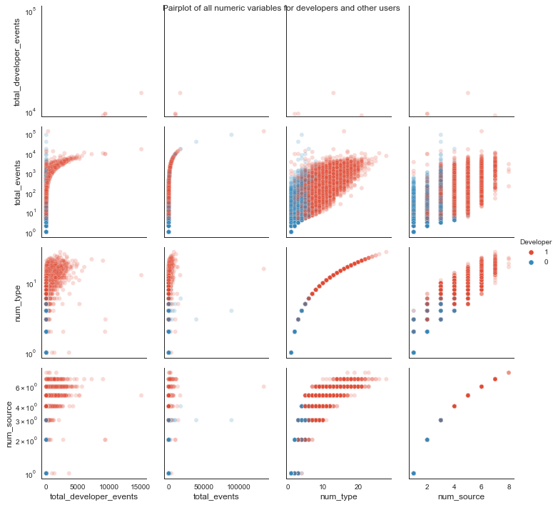

```python
g = sb.PairGrid(data = by_user2,vars=['total_developer_events','total_events','num_type','num_source'],hue = 'Active',hue_order=[1,0])
g.map(sb.scatterplot, alpha=0.2)
g.set(yscale='log')
g.fig.suptitle('Pairplot of all numeric variables for developers and other users')
g.add_legend(title='Developer');
```

- Developers turn to use more event sources than other type of users.
- Developers turn to have more types of events than other type of users.

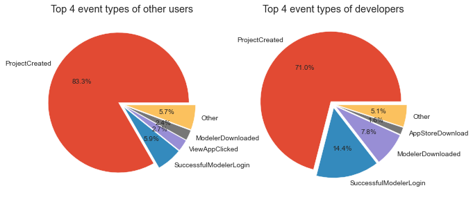

```python
# define pie chart function
def pie_plot(df1, df2, name1, name2):
    i = df1.shape[0]
    fig, ax =plt.subplots(nrows=1, ncols=2, figsize = [10,8])

    ax[0].pie(df1['perc'], autopct="%.1f%%", explode=[0.05]*i, labels= df1['First_event'].values)
    ax[0].set_title('Top 4 event types of {:s}'.format(name1))

    ax[1].pie(df2['perc'], autopct="%.1f%%", explode=[0.05]*i, labels = df2['First_event'].values)
    ax[1].set_title('Top 4 event types of {:s}'.format(name2))

pie_plot(other_type, developer_type, 'other users', 'developers')
```

- The 3 events that users perform after signup are similar.
- Except other users also view app clicked (2.7%), while developer check app store download (1.6%).
- **The starting point of developers and other users are similar.**

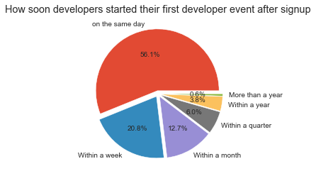

```python
# how soon developers started their first developer event after signup
by_gap = developer.groupby('gap_cat', as_index=False, dropna=False)['UserId'].count()
base = by_gap['UserId'].sum()
by_gap['gap_perc'] = by_gap['UserId'].apply(lambda x: x/base)
i= by_gap.shape[0]
plt.pie(by_gap['gap_perc'], autopct="%.1f%%", explode=[0.05]*i, labels= by_gap['gap_cat'].values)
plt.title('How soon developers started their first developer event after signup');
```

- More than half (56.1%) developers starting developing immediately after signup.
- 95.6% start within 3 months.
- The left small portion start a quarter later.
- **Old users have chance to become a developer.**

## Recommended KPIs

## MoM growth:

**Def**:

- Track month over month growth rate of developers in customer base.
- Use average mom growth rate from previous year as current year's target.

**Benefits**:

- Useful when business is in climbing phase in order to track is the accelaration rate is slower, probably signaling entering another phase.
- It can also be applied to YoY growth rate.

```
Reference: https://www.business-to-you.com/product-life-cycle/
```

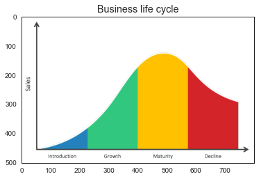

```python
import matplotlib.image as mpimg
img = mpimg.imread('Product-Life-Cycle.png')
plt.imshow(img)
plt.title('Business life cycle')
print('Reference: https://www.business-to-you.com/product-life-cycle/')
```

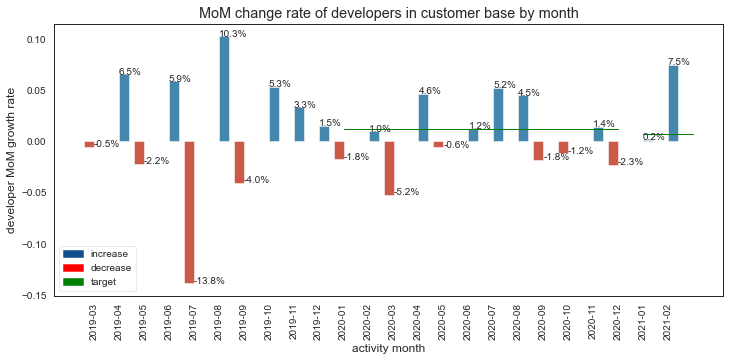

```python
# visualize accelaration rate
colors = [1 if c >= 0 else 0 for c in by_month['Developer_mom']]
plt.figure(figsize=(12,5))
sb.barplot(data=by_month.dropna(), x='Timestamp', y='Developer_mom', hue=colors)
plt.xticks(rotation=90)
blue_patch = mpatches.Patch(color='#104e8b', label='increase')
red_patch = mpatches.Patch(color='red', label='decrease')
green_patch = mpatches.Patch(color='green', label = 'target')
plt.legend(handles=[blue_patch, red_patch, green_patch])
for i in range(0, by_month.shape[0]):
    perc = by_month['Developer_mom'].iloc[i]
    perc_shown = '{:.1f}%'.format(perc*100)
    plt.text(i, perc, perc_shown, ha='left')

# set target line
x1 = np.arange(10, 22)
y1 = [mean_2019] * 12
x2 = np.arange(22, 25)
y2 = [mean_2020] * 3
plt.plot(x1 , y1, color ='green', lw = 1)
plt.plot(x2,  y2, color ='green', lw = 1)
plt.xlabel('activity month')
plt.ylabel('developer MoM growth rate')
plt.title('MoM change rate of developers in customer base by month');
```

## Developer committed time:

**Def**:

- Track trend of customer developer's committed time as payment is monthly.

**Benefits**:

- When customer developers who spend long time on platform increase, more revenue are generated, these customers also become more influential and loyal.

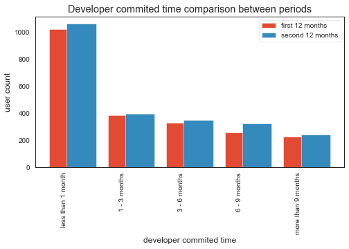

```python
# visualize and compare commited time between periods
x1 = [0, 1, 2, 3, 4]
y1 = first_12['cat'].value_counts().values
x2 = [i + 0.3 for i in x1]
y2 = second_12['cat'].value_counts().values
plt.figure(figsize=(8, 4))
bins_names = ['less than 1 month', '1 - 3 months', '3 - 6 months', '6 - 9 months', 'more than 9 months']
plt.bar(x1, y1,  width=0.5, label='first 12 months')
plt.bar(x2, y2,  width=0.5, label='second 12 months')
plt.xticks(x1, bins_names, rotation=90)
plt.legend()
plt.xlabel('developer commited time')
plt.ylabel('user count')
plt.title('Developer commited time comparison between periods');
```

# Takeaway:

- Top users still concentrate more on non developer events.
- Although developers are slightly bigger than other types of users throughout the whole period, they've very stable portion in customer base.
- Partner is still the biggest type of user, followed by customer.
- Signup boomed in 2019 Q1 and 2020 Jun, creating lots of events and users.
- Netherlands is the biggest market, US and Germany have very big potential.
- Developers turn to use more event sources and have more types of events than other type of users.
- Most developers start developing immediately after signup, however after signing up for 1 year, there's still chance for a regular user to be a developer.
- 2 KPIs are introduced.

# Future touch points:

Due to limited time and information, this analysis focuses on some sides of events and user information only, for future analysis, below points are suggested:

- Link users data to revenue model, such as type of user and their active time on platform
- Keep track customers' committed time on platform in a long run, such as how often they have activity on platform
- Keep track of other type of users, as they have chance to become developers
- Retain newly signed up customers (if think about the extreme values they brought in)